# Indian household clustering

Luke Wolcott

May 28, 2017

### The question

Is there a natural way to cluster Indian households, based on data about the nature of these households – do they have electricity, a TV, a computer, a cow, an ox-drawn cart? How do these clusters correspond to the 5-level Wealth Index?

### The dataset

The [National Family Health Survey](http://rchiips.org/nfhs/data1.shtml) is conducted in India every 10 years or so. The latest one was in 2015-2016 and the data is yet to be released. In preparation, I’m looking at the third NFHS, conducted in 2005-2006. I registered to get access to this data, (which unfortunately I can’t upload to GitHub).

This week, I’m looking at how Indian households cluster according to their characteristics. The dataset includes 109,041 separate questionnaire responses, each with 3588 (!!!) variables entered. A codebook can be found in the file `IAHR52FL.MAP` (open it with a text editor). There’s a copy of the household questionnaire starting on p.636 of `FRIND3-Vol1AndVol2.pdf`. These files are uploaded to the GitHub repo corresponding to this report.

### The variables

I will look specifically at the following variables.

| Variable | Does the household have…? | Variable | [other characteristics] |
| --- | --- | --- | --- |
| HV206 | electricity | HV025 | Rural or urban? |
| HV207 | radio | HV013 | # in household? |
| HV208 | television | HV014 | # of children in HH? |
| HV209 | refrigerator | HV216 | # of rooms for sleeping? |
| HV210 | bicycle | HV219 | sex of HH head? |
| HV211 | motorcycle/scooter | HV220 | age of HH head? |
| HV212 | car | SH30 | anyone with tuberculosis? |
| HV221 | non-mobile telephone | SH58 | own this house? |
| HV227 | bednets for sleeping | SH62A | have cows/bulls/buffalo? |
| HV243A | mobile telephone | SH62B | have camels? |
| HV243B | watch | SH62C | have horses/donkeys/mules? |
| HV243C | animal-drawn cart | SH62D | have goats? |
| HV246 | livestock | SH62E | have sheep? |
| SH47B | mattress | SH62F | have chickens? |
| SH47C | pressure cooker | SHSTRUC | nuclear or non-nuclear family? |
| SH47D | chair |  |  |
| SH47E | cot/bed |  |  |
| SH47F | table |  |  |
| SH47G | electric fan |  |  |
| SH47I | B&W television |  |  |
| SH47J | color television |  |  |
| SH47K | sewing machine |  |  |
| SH47N | computer |  |  |
| SH47U | water pump |  |  |
| SH47V | thresher |  |  |
| SH47W | tractor |  |  |
| SH56A | any windows |  |  |
| SH56B | windows with glass |  |  |
| SH56C | windows with screens |  |  |
| SH56D | windows with curtains/shutters |  |  |

### TDA to detect clusters

As a first step, we can use topological data analysis (TDA) to see if there is a natural number of clusters in the data. For the sake of computation, I’ll sample 1000 of the 109,041 cases (and remove 7 with missing data). To do the whole 993 x 44 dataset with maxscale=10, it takes my laptop about 7.5 minutes. It only took about 2 minutes with maxscale=5. Below we have the persistence homology barcode and the persistence diagram.

(See [this report](https://lukewolcott.github.io/WaterAndRainInLakeSuperior/water_and_rain.html) or [this report](https://lukewolcott.github.io/TDAwithSimulatedData/TDAwithSimulatedData.html) for some details on using TDA.)

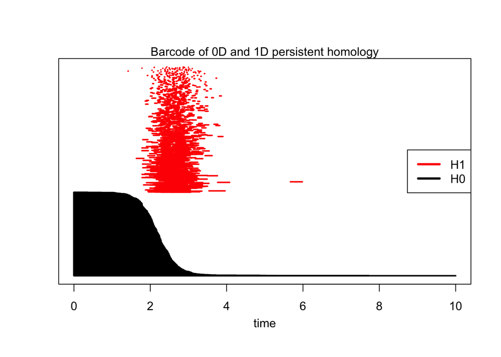

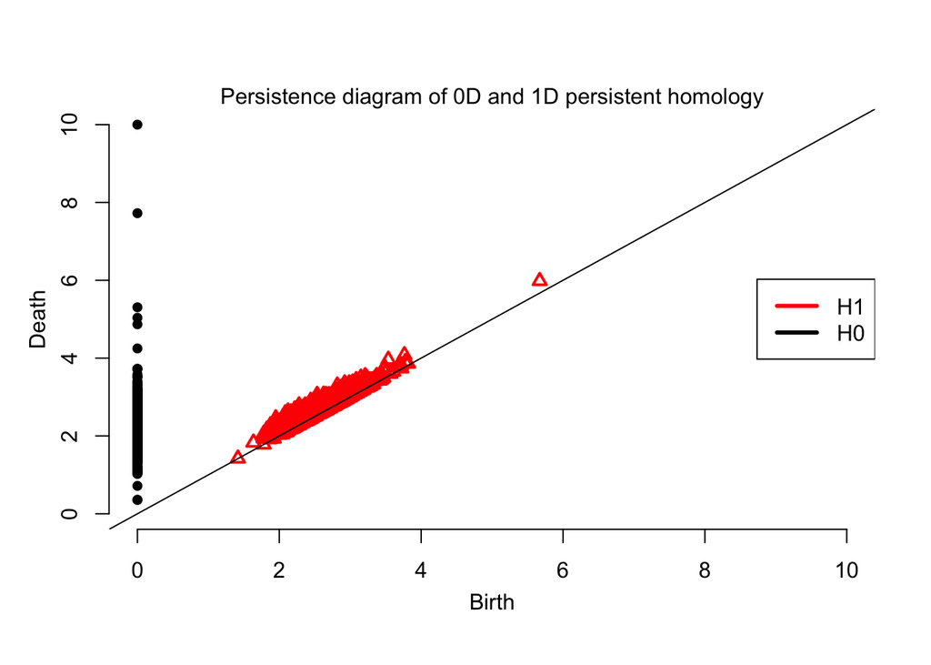

Because there are 993 black barcode lines, it’s hard to see how many larger clusters we are looking at. For this we can look explicitly at the birth and death of the H0 intervals.

```
##       dimension Birth     Death
##  [1,]         0     0 10.000000
##  [2,]         0     0  7.724024
##  [3,]         0     0  5.306447
##  [4,]         0     0  5.036054
##  [5,]         0     0  4.868821
##  [6,]         0     0  4.248221
##  [7,]         0     0  3.724490
##  [8,]         0     0  3.722570
##  [9,]         0     0  3.719849
## [10,]         0     0  3.582060
## [11,]         0     0  3.527882
## [12,]         0     0  3.520842
## [13,]         0     0  3.514229
## [14,]         0     0  3.414533
## [15,]         0     0  3.383944
```

We see that before everything gets clumped together into one connected component, there is a long stretch with two clusters. And there is a persistent feature of k=5 clusters. So, miraculously or by design, it was a good idea to use a Wealth Index with values 1-5.

### What are the two clusters?

Before we cluster with k=5, let’s see what we can say about the situation with k=2, which was suggested by TDA. It seems the two clusters have similar sizes.

```
##
##   1   2
## 519 474
```

We can tabulate the mean for each variable, grouped by cluster, to look for any large differences.

```
##   cluster2 HV025 HV206 HV207 HV208  HV209 HV210  HV211 HV212 HV219  HV221
## 1        1 0.254 0.632 0.233 0.210 0.0212 0.407 0.0405 0.000 0.832 0.0173
## 2        2 0.700 0.983 0.496 0.932 0.4599 0.489 0.3734 0.103 0.884 0.3481
##   HV227 HV243A HV243B HV243C HV246   SH30 SH47B SH47C SH47D SH47E SH47F
## 1 0.349 0.0443  0.723 0.0539 0.565 0.0154 0.482 0.214 0.426 0.755 0.308
## 2 0.426 0.4958  0.968 0.0295 0.259 0.0148 0.932 0.899 0.947 0.943 0.903
##   SH47G SH47I  SH47J  SH47K   SH47N  SH47U  SH47V   SH47W SH56A  SH56B
## 1 0.339 0.170 0.0405 0.0944 0.00193 0.0328 0.0116 0.00963 0.599 0.0539
## 2 0.861 0.245 0.7342 0.4705 0.08650 0.1540 0.0148 0.01688 0.964 0.4747
##    SH56C SH56D  SH58 SH62A   SH62B   SH62C  SH62D   SH62E SH62F SHSTRUC
## 1 0.0751 0.187 0.844 0.395 0.00578 0.00771 0.1657 0.03468 0.264   0.699
## 2 0.4030 0.605 0.827 0.169 0.00000 0.00211 0.0506 0.00422 0.120   0.565
##    HV013  HV014  HV216  HV220
## 1 -0.127  0.118 -0.287 -0.200
## 2  0.140 -0.137  0.312  0.222
```

If we plot histograms of a few of these variables, the picture emerges that cluster 1 tends to be rural households, with almost no amenities like a refrigerator or cell phone. Cluster 2 tends to be urban households, almost all electrified, and much more likely to have household amenities.

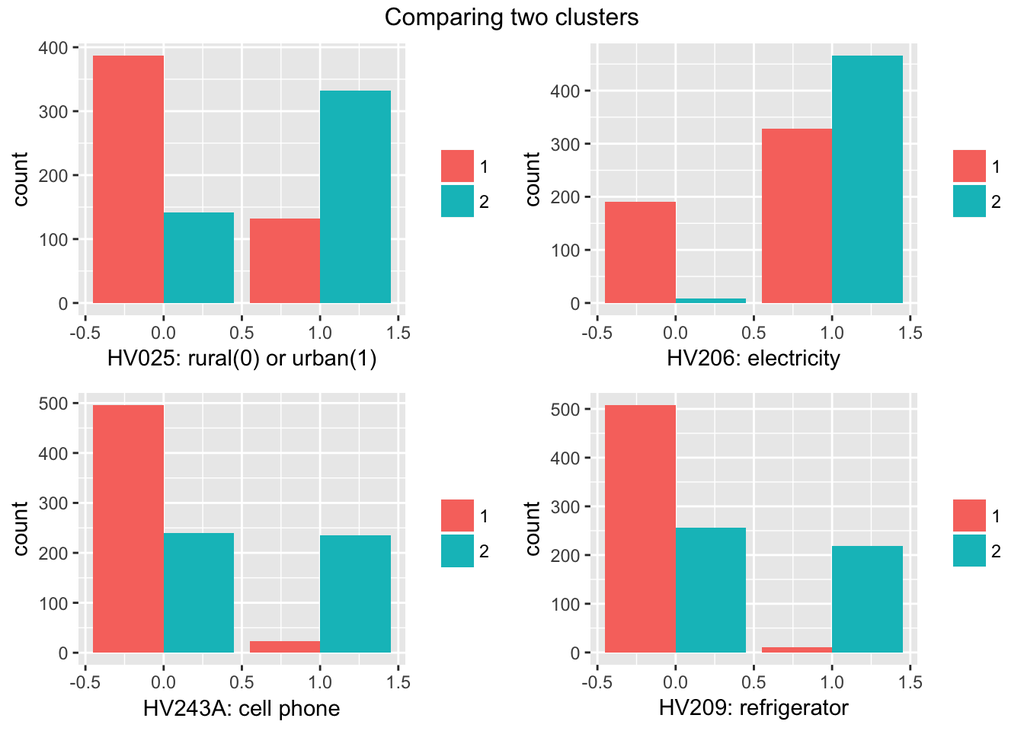

### Comparing clusters by Wealth Index

Now let’s return to the full dataset of 109,041 households, and use the same 44 variables to cluster with k=5.

The supplemental file `NFHS3SUP.pdf`, p.6, explains how the “Wealth Index” variable HV270 was constructed using PCA to generate weight for these variables. The index is a cumulative score, normalized to a ranking from 1 (poorest) to 5 (wealthiest). How do the five clusters compare with the Wealth Index?

```
##
##     Middle Poorer Poorest Richer Richest
##   1   2604   1020     293   3829    3689
##   2   4079   5386    5731   1877     211
##   3   7671   9037    8453   2040      30
##   4   6078    968      45  13512    6715
##   5    304      1       0   4000   20389
```

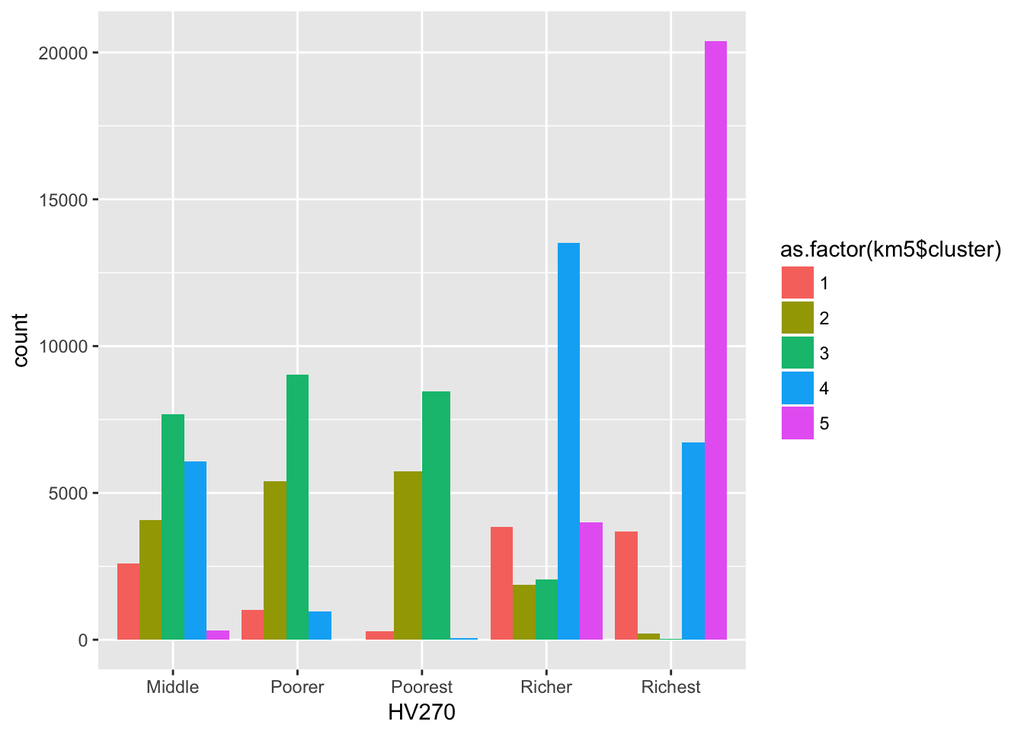